# Lab 4

Aisha Lakshman

2/15/2022

# Packages for Lab 4

```r
library(tidyverse)
```

```r
library(knitr)
library(broom)
library(ggplot2)
```

#Exploratory Data Analysis Exercise 1

```r
diamonds <- diamonds %>% filter(carat == 0.5, !is.na(carat))
```

The new dataset now has 1258 observations.

Exercise 2

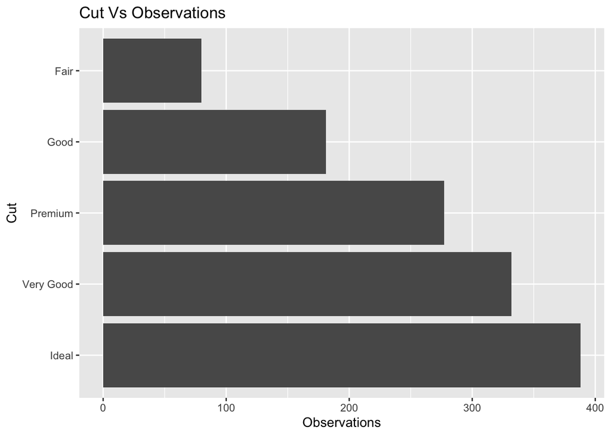

```r
ggplot(diamonds, aes(x = fct_infreq(cut))) +
  geom_bar() +
  labs (x = "Cut", y = "Observations", title = "Cut Vs Observations") +
  coord_flip()
```

The Cut vs Observations plot indicates that cut levels “fair” and “good” have the least amount of observations. Exercise 3

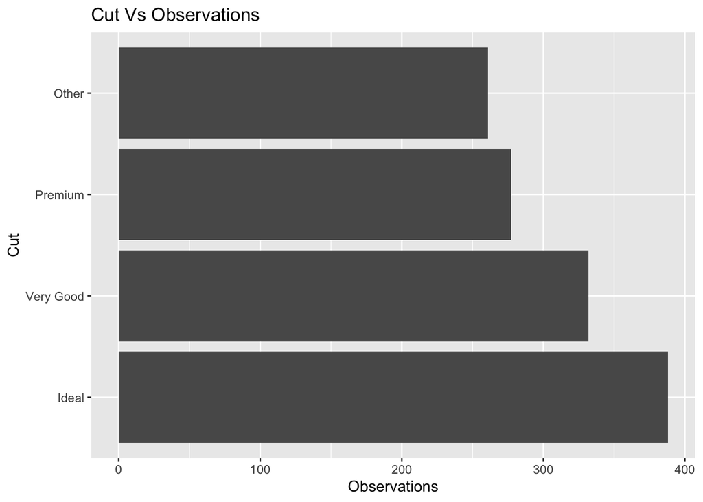

```r
diamonds <- diamonds %>% mutate(cut = fct_lump_n(cut, n = 3))
ggplot(diamonds, aes(x = fct_infreq(cut))) +
  geom_bar() +
  labs(x = "Cut", y = "Observations", title = "Cut Vs Observations") +
  coord_flip()
```

Exercise 4

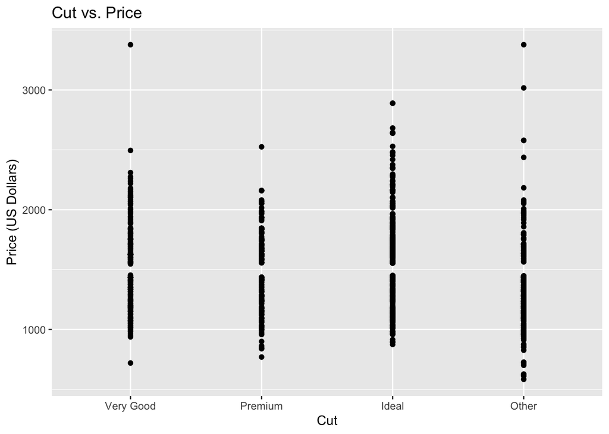

```r
ggplot(data = diamonds, mapping = aes(x = cut, y = price)) +
  geom_point(aplha = 0.5) +
  labs(x = "Cut", y = "Price (US Dollars)", title = "Cut vs. Price")
```

Exercise 5

```r
diamonds %>%
  group_by(cut) %>%
  summarise(mean = mean(price),
            std_dev = sd(price),
            num_observations = n()
  )
```

```
## # A tibble: 4 × 4
##   cut        mean std_dev num_observations
##   <ord>     <dbl>   <dbl>            <int>
## 1 Very Good 1489.    339.              332
## 2 Premium   1532.    304.              277
## 3 Ideal     1609.    368.              388
## 4 Other     1341.    365.              261
```

#Analysis of Variance

To check the normality assumption, we can create histograms for the four levels of cuts against price (compare mean price across levels of cut). If the plots follow a normal distribution, the normality assumption is satsified.

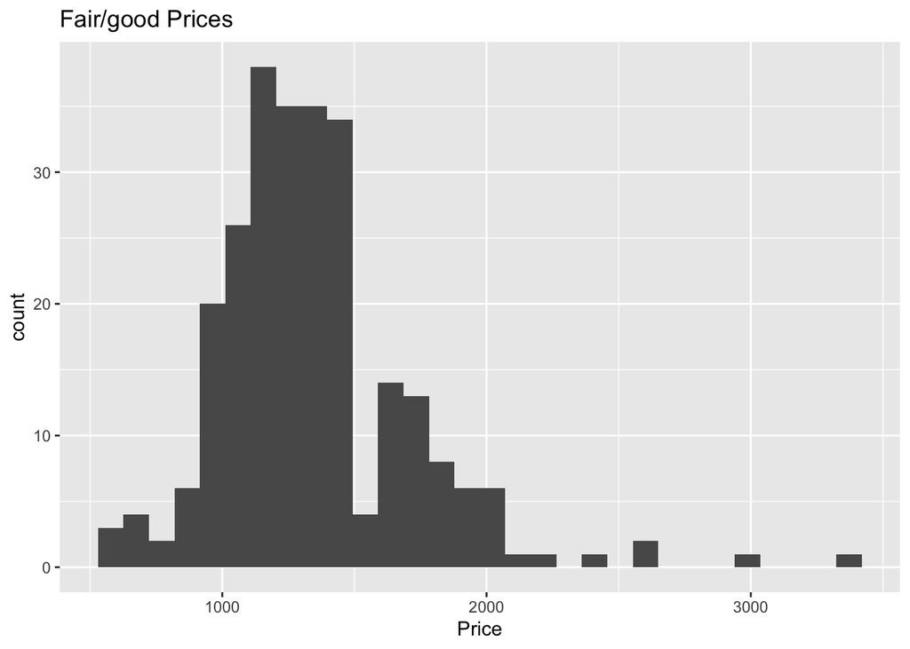

```r
fair_good_cut <- diamonds %>%
  filter(cut == "Other")
ggplot(data = fair_good_cut, aes(x = price)) +
  geom_histogram() +
  labs(title = "Fair/good Prices ",
       x = "Price")
```

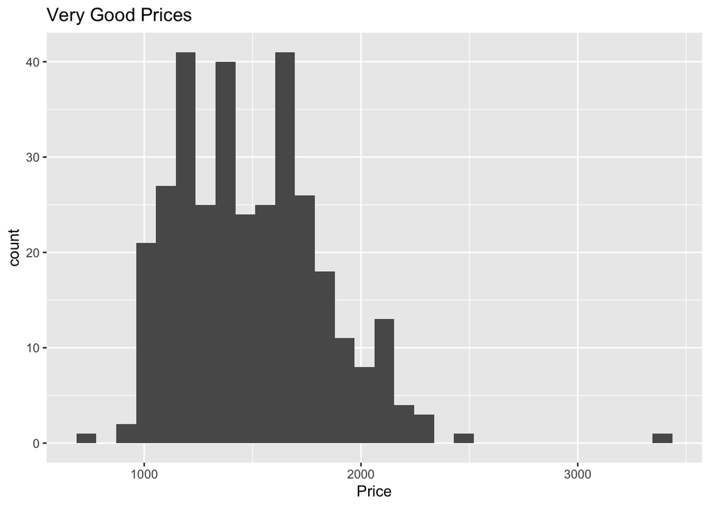

```r
very_good_cut <- diamonds %>%
  filter(cut == "Very Good")
ggplot(data = very_good_cut, aes(x = price)) +
  geom_histogram() +
  labs(title = "Very Good Prices",
       x = "Price")
```

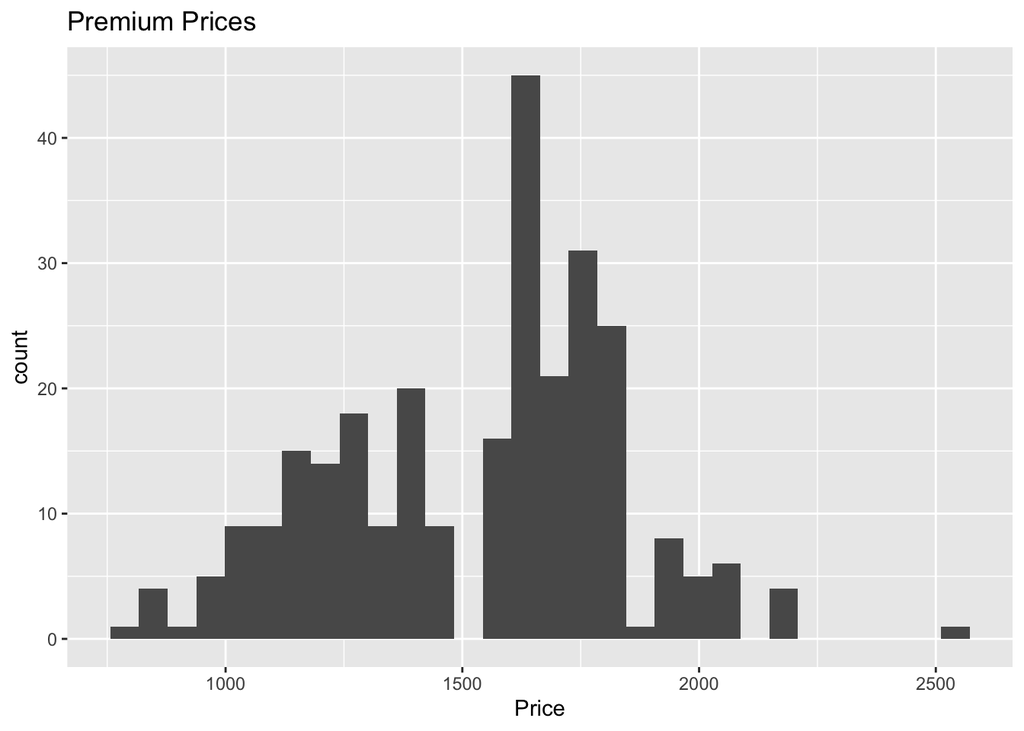

```r
premium_cut <- diamonds %>%
  filter(cut == "Premium")
ggplot(data = premium_cut, aes(x = price)) +
  geom_histogram() +
  labs(title = "Premium Prices",
       x = "Price")
```

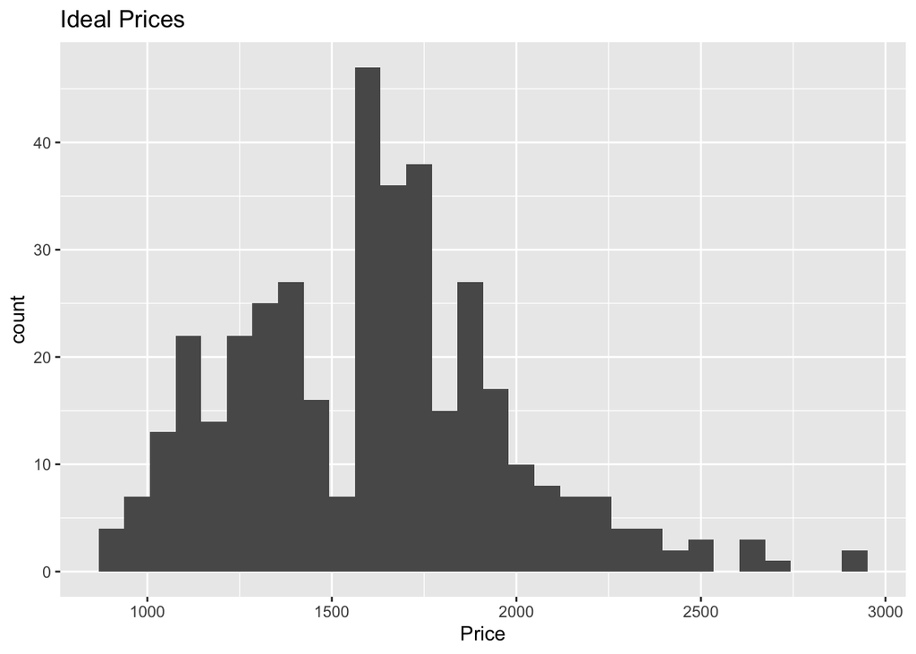

```r
ideal_cut <- diamonds %>%
  filter(cut == "Ideal")
ggplot(data = ideal_cut, aes(x = price)) +
  geom_histogram() +
  labs(title = "Ideal Prices",
       x = "Price")
```

There is no formal test to check for independence, so we have to inspect how our data was collected. I would say the independence assumption is satisfied because each observation are not dependent on another.

To test the constant variance assumption, we can create a model and adapt our code above to plot price against the residuals. We can visually inspect the variance by inspecting the length of each boxplot.

```r
model <- lm(price ~ cut, data = diamonds)
tidy(model) %>%
  kable(format="markdown", digits=3)
```

| term | estimate | std.error | statistic | p.value |
| --- | --- | --- | --- | --- |
| (Intercept) | 1492.438 | 9.893 | 150.852 | 0 |
| cut.L | -82.101 | 20.181 | -4.068 | 0 |
| cut.Q | -155.569 | 19.787 | -7.862 | 0 |
| cut.C | -84.678 | 19.384 | -4.368 | 0 |

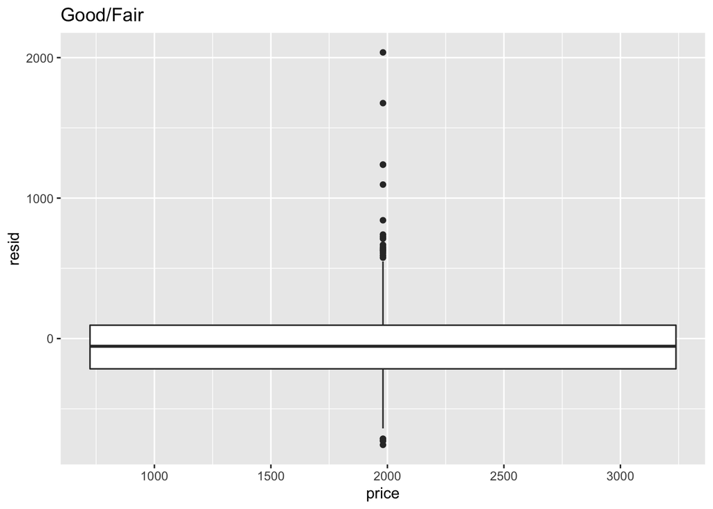

```r
diamonds <- diamonds %>%
  mutate(resid = residuals(model))

fair_good_cut <- diamonds %>%
  filter(cut == "Other")
ggplot(data = fair_good_cut, aes(x = price, y = resid)) +
  geom_boxplot() + labs(title = "Good/Fair")
```

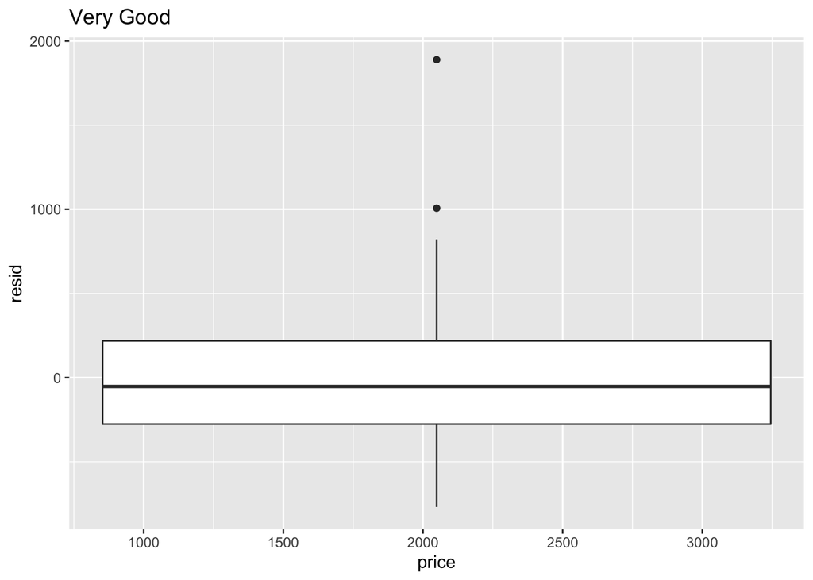

```r
very_good_cut <- diamonds %>%
  filter(cut == "Very Good")
ggplot(data = very_good_cut, aes(x = price, y = resid)) +
  geom_boxplot() + labs(title = "Very Good")
```

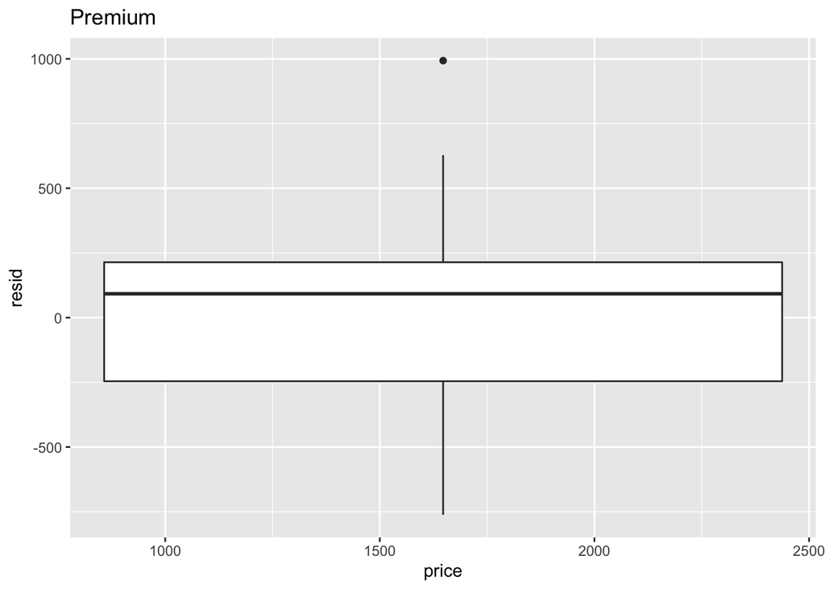

```r
premium_cut <- diamonds %>%
  filter(cut == "Premium")
ggplot(data = premium_cut, aes(x = price, y = resid)) +
  geom_boxplot() + labs(title = "Premium")
```

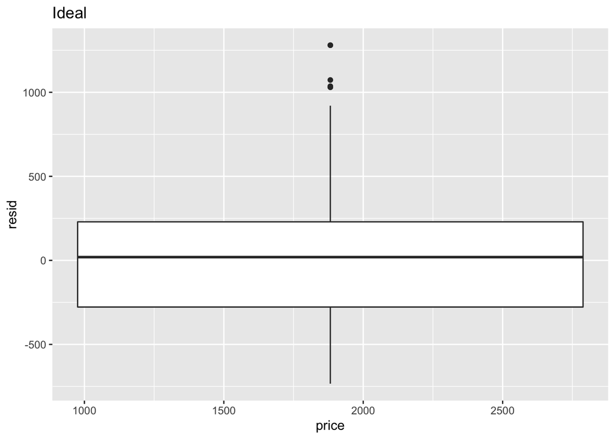

```r
ideal_cut <- diamonds %>%
  filter(cut == "Ideal")
ggplot(data = ideal_cut, aes(x = price, y = resid)) +
  geom_boxplot() + labs(title = "Ideal")
```

I would say that the constant variance assumption is not satisfied because the lengths of each boxplot are not the same. If the sample sizes for each cut level were the same, the variance assumption could be satisfied, but in this case they are not.

Exercise 8

```r
model <- lm(price ~ cut, data = diamonds)
kable(anova(model), format="markdown",digits=6)
```

|  | Df | Sum Sq | Mean Sq | F value | Pr(>F) |
| --- | --- | --- | --- | --- | --- |
| cut | 3 | 11507056 | 3835685.3 | 31.916 | 0 |
| Residuals | 1254 | 150706506 | 120180.6 | NA | NA |

```r
sum_of_sqaures <- 150706506
obs_num <- 1258
sample_variance_price <- sum_of_sqaures/obs_num
sample_variance_price
```

```
## [1] 119798.5
```

Exercise 10

```r
tidy(model) %>%
  kable(format = "markdown", digits = 3)
```

| term | estimate | std.error | statistic | p.value |
| --- | --- | --- | --- | --- |
| (Intercept) | 1492.438 | 9.893 | 150.852 | 0 |
| cut.L | -82.101 | 20.181 | -4.068 | 0 |
| cut.Q | -155.569 | 19.787 | -7.862 | 0 |
| cut.C | -84.678 | 19.384 | -4.368 | 0 |

```r
summary(model)$coef[,2]
```

```
## (Intercept)       cut.L       cut.Q       cut.C
##    9.893372   20.181275   19.786744   19.384185
```

Exercise 11 Math notation null_hypothesis = (mean(price: cut = ideal) = (mean(price: cut = premium) = (mean(price: cut = very good) = (mean(price: cut = other). alternative_hypothesis = !(mean(price: cut = ideal) = (mean(price: cut = premium) = (mean(price: cut = very good) = (mean(price: cut = other) The null hypothesis states that means of price are the same among each level of cut. The alternative hypothesis states that at least one price mean is not equal to other price means among each level of cut.

Exercise 12 I would reject the null hypothesis and accept the alternative hypothesis because there seems to be a statistically significant relationship between price and level of cut.

Exercise 13 I would say no further statistical analysis is required because there is a statistically significant relationship between price and level of cut.